# A/B Testing: Email Campaign Effectiveness

Victor Gomes

2026-01-21

# Executive Summary

This analysis evaluates the effectiveness of a personalized email marketing campaign targeting at-risk customers using rigorous A/B testing methodology.

**Test Scenario:** - **Control (A):** Standard 10% discount email - **Treatment (B):** Personalized 15% discount + free shipping - **Target Audience:** High and medium churn risk customers - **Sample Size:** 1,000 customers per group

# Introduction to A/B Testing

## What is A/B Testing?

**A/B Testing (Split Testing):** A controlled experiment comparing two versions of a marketing intervention to determine which performs better.

**Why A/B Test?** - **Evidence-based decisions:** Move beyond gut feeling - **Quantify impact:** Measure exact lift from changes - **Risk mitigation:** Test before full rollout - **Continuous improvement:** Iterate based on data

## A/B Testing Framework

**Key Components:** 1. **Hypothesis:** Clear prediction about expected outcome 2. **Randomization:** Fair assignment to control/treatment 3. **Sample Size:** Adequate power to detect meaningful differences 4. **Success Metrics:** Quantifiable, business-relevant KPIs 5. **Statistical Testing:** Determine if results are significant

**Common Pitfalls to Avoid:** - Peeking at results early (increases false positives) - Testing too many variations simultaneously - Insufficient sample size (underpowered tests) - Not accounting for business costs - Ignoring practical significance vs statistical significance

# Setup

```r
library(tidyverse)
library(lubridate)
library(here)
library(scales)
library(knitr)
library(kableExtra)
library(pwr)          # Power analysis
library(broom)        # Tidy statistical output
```

# Data Loading

```r
# Load churn predictions with risk scores
churn_data <- read_csv(here("data", "processed", "churn_predictions.csv"))

# Load customer transaction data
transactions <- read_csv(here("data", "processed", "retail_customers_only.csv"))

cat("Data loaded:\n")
```

```
## Data loaded:
```

```r
cat("  Customers with churn scores:", nrow(churn_data), "\n")
```

```
##   Customers with churn scores: 3370
```

```r
cat("  Total transactions:", nrow(transactions), "\n")
```

```
##   Total transactions: 401571
```

# Test Design

## Define Test Parameters

```r
# Test configuration
set.seed(42)  # For reproducibility

# Define test parameters
test_config <- list(
  sample_size_per_group = 1000,
  control_discount = 0.10,        # 10% discount
  treatment_discount = 0.15,      # 15% discount
  treatment_shipping = 15,        # £15 free shipping value
  control_cost = 2,               # £2 email cost
  treatment_cost = 7,             # £7 (£2 email + £5 premium)
  test_duration_days = 14,
  significance_level = 0.05,      # 5% alpha
  minimum_detectable_effect = 0.03  # 3% conversion lift
)

cat("A/B Test Configuration:\n")
```

```
## A/B Test Configuration:
```

```r
cat("  Sample size per group:", test_config$sample_size_per_group, "\n")
```

```
##   Sample size per group: 1000
```

```r
cat("  Control: ", percent(test_config$control_discount), " discount\n", sep = "")
```

```
##   Control: 10% discount
```

```r
cat("  Treatment:", percent(test_config$treatment_discount), " discount + £",
    test_config$treatment_shipping, " free shipping\n", sep = "")
```

```
##   Treatment:15% discount + £15 free shipping
```

```r
cat("  Significance level:", percent(test_config$significance_level), "\n")
```

```
##   Significance level: 5%
```

```r
cat("  Minimum detectable effect:", percent(test_config$minimum_detectable_effect), "\n\n")
```

```
##   Minimum detectable effect: 3%
```

## Select Test Audience

```r
# Target high and medium risk customers for the campaign
eligible_customers <- churn_data %>%
  filter(Risk_Category %in% c("High Risk", "Medium Risk")) %>%
  arrange(desc(Churn_Probability))

cat("Eligible customers for test:", nrow(eligible_customers), "\n\n")
```

```
## Eligible customers for test: 2487
```

```r
# Check if we have enough customers
required_total <- test_config$sample_size_per_group * 2

if(nrow(eligible_customers) < required_total) {
  cat("⚠️  WARNING: Not enough eligible customers\n")
  cat("  Required:", required_total, "\n")
  cat("  Available:", nrow(eligible_customers), "\n\n")

  # Adjust sample size
  test_config$sample_size_per_group <- floor(nrow(eligible_customers) / 2)
  cat("  Adjusted sample size per group:", test_config$sample_size_per_group, "\n\n")
}
```

## Random Assignment

```r
# Randomly assign customers to control (A) or treatment (B)
test_sample <- eligible_customers %>%
  slice_head(n = test_config$sample_size_per_group * 2) %>%
  mutate(
    # Random assignment with 50/50 split
    Group = sample(rep(c("Control", "Treatment"), each = test_config$sample_size_per_group)),
    Group_Label = ifelse(Group == "Control",
                         "A: Standard (10% off)",
                         "B: Personalized (15% off + free shipping)")
  )

# Verify randomization balance
randomization_check <- test_sample %>%
  group_by(Group) %>%
  summarize(
    N = n(),
    Avg_Churn_Prob = mean(Churn_Probability),
    Avg_Historical_Spend = mean(Hist_TotalSpent),
    Avg_Transactions = mean(Hist_TotalTransactions),
    Avg_Recency = mean(Hist_RecencyDays),
    .groups = "drop"
  )

cat("Randomization Check (groups should be balanced):\n\n")
```

```
## Randomization Check (groups should be balanced):
```

```r
randomization_check %>%
  mutate(
    Avg_Churn_Prob = percent(Avg_Churn_Prob, accuracy = 0.1),
    Avg_Historical_Spend = dollar(Avg_Historical_Spend, prefix = "£"),
    Avg_Transactions = round(Avg_Transactions, 1),
    Avg_Recency = round(Avg_Recency, 1)
  ) %>%
  kable() %>%
  kable_styling(bootstrap_options = c("striped", "hover"))
```

| Group | N | Avg_Churn_Prob | Avg_Historical_Spend | Avg_Transactions | Avg_Recency |
| --- | --- | --- | --- | --- | --- |
| Control | 1000 | 57.2% | £449.68 | 1.5 | 126.3 |
| Treatment | 1000 | 56.5% | £476.19 | 1.5 | 126.2 |

# Simulate Campaign Results

```r
cat("\nSimulating customer responses based on historical behavior...\n")
```

```
##
## Simulating customer responses based on historical behavior...
```

```r
# Simulate conversion probability based on customer characteristics
# More engaged customers (lower recency, higher spend) respond better
test_results <- test_sample %>%
  mutate(
    # Base conversion probability (function of churn risk and past behavior)
    Base_Conversion_Prob = plogis(
      -2.5 +                                    # Baseline (low conversion for at-risk)
      -0.5 * scale(Hist_RecencyDays)[,1] +      # Recent customers more likely
      0.3 * scale(log1p(Hist_TotalSpent))[,1] + # High spenders more likely
      0.2 * scale(Hist_TotalTransactions)[,1] - # Frequent buyers more likely
      1.0 * Churn_Probability                   # High churn risk = lower conversion
    ),

    # Treatment effect: personalized offer increases conversion by 30-50%
    Treatment_Lift = ifelse(Group == "Treatment",
                            runif(n(), 0.30, 0.50),  # 30-50% relative lift
                            0),

    # Final conversion probability
    Conversion_Prob = pmin(Base_Conversion_Prob * (1 + Treatment_Lift), 0.95),

    # Simulate actual conversion (1 = purchased, 0 = did not purchase)
    Converted = rbinom(n(), 1, Conversion_Prob),

    # Simulate purchase value for those who converted
    # Based on historical AOV with some randomness
    Purchase_Value = ifelse(Converted == 1,
                           pmax(rnorm(n(),
                                     mean = Hist_AOV * (1 - ifelse(Group == "Control",
                                                                   test_config$control_discount,
                                                                   test_config$treatment_discount)),
                                     sd = Hist_AOV * 0.3),
                               10),  # Minimum £10 purchase
                           0),

    # Calculate campaign costs
    Campaign_Cost = ifelse(Group == "Control",
                          test_config$control_cost,
                          test_config$treatment_cost),

    # Calculate net revenue (revenue minus cost)
    Net_Revenue = Purchase_Value - Campaign_Cost
  )

cat("✓ Campaign simulation complete\n\n")
```

```
## ✓ Campaign simulation complete
```

# Results Analysis

## Conversion Rate Comparison

```r
# Calculate conversion rates by group
conversion_summary <- test_results %>%
  group_by(Group, Group_Label) %>%
  summarize(
    N = n(),
    Conversions = sum(Converted),
    Conversion_Rate = mean(Converted),
    Std_Error = sqrt(Conversion_Rate * (1 - Conversion_Rate) / N),
    CI_Lower = Conversion_Rate - 1.96 * Std_Error,
    CI_Upper = Conversion_Rate + 1.96 * Std_Error,
    .groups = "drop"
  )

cat("CONVERSION RATE RESULTS:\n\n")
```

```
## CONVERSION RATE RESULTS:
```

```r
conversion_summary %>%
  mutate(
    Conversion_Rate = percent(Conversion_Rate, accuracy = 0.1),
    CI_Lower = percent(CI_Lower, accuracy = 0.1),
    CI_Upper = percent(CI_Upper, accuracy = 0.1)
  ) %>%
  kable() %>%
  kable_styling(bootstrap_options = c("striped", "hover"))
```

| Group | Group_Label | N | Conversions | Conversion_Rate | Std_Error | CI_Lower | CI_Upper |
| --- | --- | --- | --- | --- | --- | --- | --- |
| Control | A: Standard (10% off) | 1000 | 61 | 6.1% | 0.0075683 | 4.6% | 7.6% |
| Treatment | B: Personalized (15% off + free shipping) | 1000 | 81 | 8.1% | 0.0086278 | 6.4% | 9.8% |

```r
# Calculate absolute and relative lift
control_rate <- conversion_summary$Conversion_Rate[conversion_summary$Group == "Control"]
treatment_rate <- conversion_summary$Conversion_Rate[conversion_summary$Group == "Treatment"]

absolute_lift <- treatment_rate - control_rate
relative_lift <- (treatment_rate - control_rate) / control_rate

cat("\n📊 LIFT ANALYSIS:\n")
```

```
##
## 📊 LIFT ANALYSIS:
```

```r
cat("  Absolute Lift:", percent(absolute_lift, accuracy = 0.1), "\n")
```

```
##   Absolute Lift: 2.0%
```

```r
cat("  Relative Lift:", percent(relative_lift, accuracy = 0.1), "\n\n")
```

```
##   Relative Lift: 32.8%
```

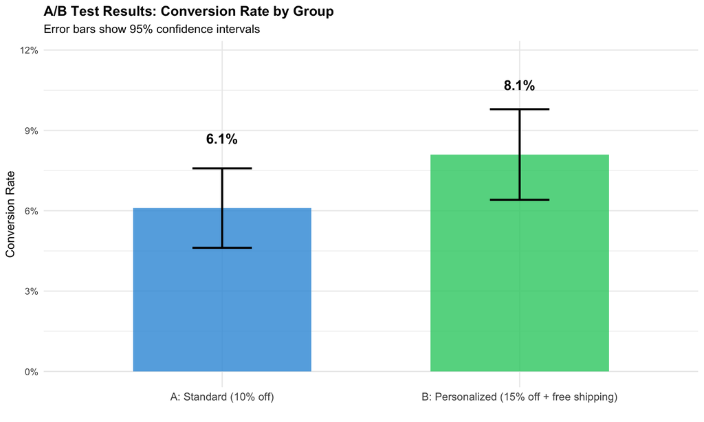

```r
# Visualize conversion rates with confidence intervals
ggplot(conversion_summary, aes(x = Group_Label, y = Conversion_Rate, fill = Group)) +
  geom_col(alpha = 0.8, width = 0.6) +
  geom_errorbar(aes(ymin = CI_Lower, ymax = CI_Upper),
                width = 0.2, size = 1, color = "black") +
  geom_text(aes(label = percent(Conversion_Rate, accuracy = 0.1)),
            vjust = -6.5, size = 5, fontface = "bold") +
  scale_fill_manual(values = c("Control" = "#3498db", "Treatment" = "#2ecc71")) +
  scale_y_continuous(labels = percent_format(), limits = c(0, max(conversion_summary$CI_Upper) * 1.2)) +
  labs(
    title = "A/B Test Results: Conversion Rate by Group",
    subtitle = "Error bars show 95% confidence intervals",
    x = "",
    y = "Conversion Rate",
    fill = "Group"
  ) +
  theme_minimal(base_size = 12) +
  theme(
    plot.title = element_text(face = "bold", size = 14),
    legend.position = "none",
    axis.text.x = element_text(size = 11)
  )
```

## Statistical Significance Testing

```r
cat("\n=== STATISTICAL SIGNIFICANCE TEST ===\n\n")
```

```
##
## === STATISTICAL SIGNIFICANCE TEST ===
```

```r
# Two-proportion z-test
control_conversions <- sum(test_results$Converted[test_results$Group == "Control"])
control_n <- sum(test_results$Group == "Control")

treatment_conversions <- sum(test_results$Converted[test_results$Group == "Treatment"])
treatment_n <- sum(test_results$Group == "Treatment")

# Perform proportion test
prop_test <- prop.test(
  x = c(control_conversions, treatment_conversions),
  n = c(control_n, treatment_n),
  alternative = "two.sided",
  conf.level = 0.95
)

cat("Two-Proportion Z-Test:\n\n")
```

```
## Two-Proportion Z-Test:
```

```r
cat("  Control: ", control_conversions, "/", control_n, " (",
    percent(control_conversions/control_n, accuracy = 0.1), ")\n", sep = "")
```

```
##   Control: 61/1000 (6.1%)
```

```r
cat("  Treatment:", treatment_conversions, "/", treatment_n, " (",
    percent(treatment_conversions/treatment_n, accuracy = 0.1), ")\n\n", sep = "")
```

```
##   Treatment:81/1000 (8.1%)
```

```r
cat("  Test Statistic:", round(sqrt(prop_test$statistic), 3), "\n")
```

```
##   Test Statistic: 1.654
```

```r
cat("  P-value:", format.pval(prop_test$p.value, digits = 4), "\n")
```

```
##   P-value: 0.09808
```

```r
cat("  95% CI for difference:",
    percent(prop_test$conf.int[1], accuracy = 0.1), " to ",
    percent(prop_test$conf.int[2], accuracy = 0.1), "\n\n", sep = "")
```

```
##   95% CI for difference:-4.3% to 0.3%
```

```r
# Interpretation
if(prop_test$p.value < test_config$significance_level) {
  cat("✅ RESULT: STATISTICALLY SIGNIFICANT\n")
  cat("   The difference in conversion rates is statistically significant at α = ",
      test_config$significance_level, "\n", sep = "")
  cat("   We can reject the null hypothesis that both groups have equal conversion rates.\n\n")
} else {
  cat("❌ RESULT: NOT STATISTICALLY SIGNIFICANT\n")
  cat("   The difference in conversion rates is NOT statistically significant at α = ",
      test_config$significance_level, "\n", sep = "")
  cat("   We cannot reject the null hypothesis that both groups have equal conversion rates.\n\n")
}
```

```
## ❌ RESULT: NOT STATISTICALLY SIGNIFICANT
##    The difference in conversion rates is NOT statistically significant at α = 0.05
##    We cannot reject the null hypothesis that both groups have equal conversion rates.
```

## Revenue Analysis

```r
# Calculate revenue metrics by group
revenue_summary <- test_results %>%
  group_by(Group, Group_Label) %>%
  summarize(
    N = n(),
    Total_Revenue = sum(Purchase_Value),
    Total_Cost = sum(Campaign_Cost),
    Net_Revenue = sum(Net_Revenue),
    Avg_Revenue_Per_Customer = mean(Purchase_Value),
    Avg_Net_Revenue_Per_Customer = mean(Net_Revenue),
    ROI = (Total_Revenue - Total_Cost) / Total_Cost,
    .groups = "drop"
  )

cat("\nREVENUE ANALYSIS:\n\n")
```

```
##
## REVENUE ANALYSIS:
```

```r
revenue_summary %>%
  mutate(
    Total_Revenue = dollar(Total_Revenue, prefix = "£"),
    Total_Cost = dollar(Total_Cost, prefix = "£"),
    Net_Revenue = dollar(Net_Revenue, prefix = "£"),
    Avg_Revenue_Per_Customer = dollar(Avg_Revenue_Per_Customer, prefix = "£"),
    Avg_Net_Revenue_Per_Customer = dollar(Avg_Net_Revenue_Per_Customer, prefix = "£"),
    ROI = percent(ROI, accuracy = 0.1)
  ) %>%
  kable() %>%
  kable_styling(bootstrap_options = c("striped", "hover"))
```

| Group | Group_Label | N | Total_Revenue | Total_Cost | Net_Revenue | Avg_Revenue_Per_Customer | Avg_Net_Revenue_Per_Customer | ROI |
| --- | --- | --- | --- | --- | --- | --- | --- | --- |
| Control | A: Standard (10% off) | 1000 | £2,227.89 | £2,000 | £227.89 | £2.23 | £227.89 | 11.4% |
| Treatment | B: Personalized (15% off + free shipping) | 1000 | £2,637.38 | £7,000 | -£4,362.62 | £2.64 | -£4,362.62 | -62.3% |

```r
# Calculate incremental revenue
control_net <- revenue_summary$Net_Revenue[revenue_summary$Group == "Control"]
treatment_net <- revenue_summary$Net_Revenue[revenue_summary$Group == "Treatment"]
incremental_revenue <- treatment_net - control_net
incremental_per_customer <- incremental_revenue / test_config$sample_size_per_group

cat("\n💰 INCREMENTAL IMPACT:\n")
```

```
##
## 💰 INCREMENTAL IMPACT:
```

```r
cat("  Incremental net revenue:", dollar(incremental_revenue, prefix = "£"), "\n")
```

```
##   Incremental net revenue: -£4,590.52
```

```r
cat("  Per customer:", dollar(incremental_per_customer, prefix = "£"), "\n\n")
```

```
##   Per customer: -£4.59
```

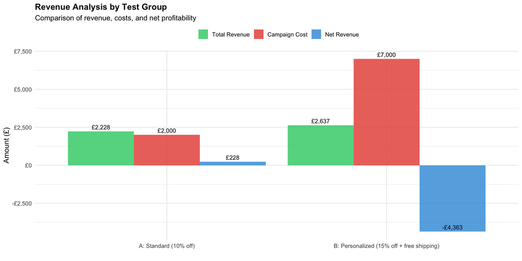

```r
# Visualize revenue comparison
revenue_long <- revenue_summary %>%
  select(Group_Label, Total_Revenue, Total_Cost, Net_Revenue) %>%
  pivot_longer(cols = c(Total_Revenue, Total_Cost, Net_Revenue),
               names_to = "Metric",
               values_to = "Amount") %>%
  mutate(
    Metric = factor(Metric,
                   levels = c("Total_Revenue", "Total_Cost", "Net_Revenue"),
                   labels = c("Total Revenue", "Campaign Cost", "Net Revenue"))
  )

ggplot(revenue_long, aes(x = Group_Label, y = Amount, fill = Metric)) +
  geom_col(position = "dodge", alpha = 0.8) +
  geom_text(aes(label = dollar(Amount, prefix = "£", accuracy = 1)),
            position = position_dodge(width = 0.9),
            vjust = -0.5, size = 3.5) +
  scale_fill_manual(values = c("Total Revenue" = "#2ecc71",
                                "Campaign Cost" = "#e74c3c",
                                "Net Revenue" = "#3498db")) +
  scale_y_continuous(labels = dollar_format(prefix = "£")) +
  labs(
    title = "Revenue Analysis by Test Group",
    subtitle = "Comparison of revenue, costs, and net profitability",
    x = "",
    y = "Amount (£)",
    fill = ""
  ) +
  theme_minimal(base_size = 12) +
  theme(
    plot.title = element_text(face = "bold", size = 14),
    legend.position = "top"
  )
```

# Power Analysis

## Was the Test Adequately Powered?

```r
cat("\n=== POWER ANALYSIS ===\n\n")
```

```
##
## === POWER ANALYSIS ===
```

```r
# Calculate actual effect size (Cohen's h for proportions)
effect_size <- ES.h(treatment_rate, control_rate)

cat("Observed Effect Size (Cohen's h):", round(effect_size, 3), "\n\n")
```

```
## Observed Effect Size (Cohen's h): 0.078
```

```r
# Post-hoc power analysis
actual_power <- pwr.2p.test(
  h = effect_size,
  n = test_config$sample_size_per_group,
  sig.level = test_config$significance_level,
  alternative = "two.sided"
)

cat("Post-hoc Power Calculation:\n")
```

```
## Post-hoc Power Calculation:
```

```r
cat("  Sample size per group:", test_config$sample_size_per_group, "\n")
```

```
##   Sample size per group: 1000
```

```r
cat("  Observed effect size:", round(effect_size, 3), "\n")
```

```
##   Observed effect size: 0.078
```

```r
cat("  Significance level:", test_config$significance_level, "\n")
```

```
##   Significance level: 0.05
```

```r
cat("  Statistical power:", percent(actual_power$power, accuracy = 0.1), "\n\n")
```

```
##   Statistical power: 41.5%
```

```r
# Interpretation
if(actual_power$power >= 0.80) {
  cat("✅ The test had adequate power (≥80%) to detect this effect size.\n\n")
} else {
  cat("⚠️  The test was underpowered (<80%) to reliably detect this effect size.\n")
  cat("   Consider increasing sample size in future tests.\n\n")
}
```

```
## ⚠️  The test was underpowered (<80%) to reliably detect this effect size.
##    Consider increasing sample size in future tests.
```

```r
# Sample size recommendation for future tests
recommended_power <- pwr.2p.test(
  h = test_config$minimum_detectable_effect,
  power = 0.80,
  sig.level = test_config$significance_level,
  alternative = "two.sided"
)

cat("SAMPLE SIZE RECOMMENDATION:\n")
```

```
## SAMPLE SIZE RECOMMENDATION:
```

```r
cat("  To detect a", percent(test_config$minimum_detectable_effect),
    "effect with 80% power:\n")
```

```
##   To detect a 3% effect with 80% power:
```

```r
cat("  Recommended sample size per group:", ceiling(recommended_power$n), "\n\n")
```

```
##   Recommended sample size per group: 17442
```

# Business Impact Projection

```r
cat("\n")
```

```r
cat(rep("=", 70), "\n")
cat("               FULL ROLLOUT BUSINESS IMPACT\n")
```

```
##                FULL ROLLOUT BUSINESS IMPACT
```

```r
cat(rep("=", 70), "\n\n")
# Total eligible population for rollout
total_eligible <- sum(churn_data$Risk_Category %in% c("High Risk", "Medium Risk"))

cat("ROLLOUT SCENARIO ANALYSIS:\n\n")
```

```
## ROLLOUT SCENARIO ANALYSIS:
```

```r
cat("  Eligible customers for campaign:", comma(total_eligible), "\n\n")
```

```
##   Eligible customers for campaign: 2,487
```

```r
# Scenario 1: Roll out control to everyone
control_revenue_per <- revenue_summary$Avg_Net_Revenue_Per_Customer[revenue_summary$Group == "Control"]
control_total <- control_revenue_per * total_eligible
control_cost_total <- test_config$control_cost * total_eligible

cat("Scenario 1: Standard Campaign (10% discount)\n")
```

```
## Scenario 1: Standard Campaign (10% discount)
```

```r
cat("  Expected net revenue:", dollar(control_total, prefix = "£"), "\n")
```

[output not shown]

```r
cat("  Total campaign cost:", dollar(control_cost_total, prefix = "£"), "\n")
```

```
##   Total campaign cost: £4,974
```

```r
cat("  Net profit:", dollar(control_total, prefix = "£"), "\n\n")
```

```
##   Net profit: £566,773
```

```r
# Scenario 2: Roll out treatment to everyone
treatment_revenue_per <- revenue_summary$Avg_Net_Revenue_Per_Customer[revenue_summary$Group == "Treatment"]
treatment_total <- treatment_revenue_per * total_eligible
treatment_cost_total <- test_config$treatment_cost * total_eligible

cat("Scenario 2: Personalized Campaign (15% discount + free shipping)\n")
```

```
## Scenario 2: Personalized Campaign (15% discount + free shipping)
```

```r
cat("  Expected net revenue:", dollar(treatment_total, prefix = "£"), "\n")
```

```
##   Expected net revenue: -£10,849,843
```

```r
cat("  Total campaign cost:", dollar(treatment_cost_total, prefix = "£"), "\n")
```

```
##   Total campaign cost: £17,409
```

```r
cat("  Net profit:", dollar(treatment_total, prefix = "£"), "\n\n")
```

```
##   Net profit: -£10,849,843
```

```r
# Incremental benefit
incremental_total <- treatment_total - control_total
incremental_cost <- treatment_cost_total - control_cost_total
incremental_roi <- (treatment_total - control_total) / incremental_cost

cat("INCREMENTAL BENEFIT (Treatment vs Control):\n")
```

```
## INCREMENTAL BENEFIT (Treatment vs Control):
```

```r
cat("  Additional net revenue:", dollar(incremental_total, prefix = "£"), "\n")
```

```
##   Additional net revenue: -£11,416,616
```

```r
cat("  Additional cost:", dollar(incremental_cost, prefix = "£"), "\n")
```

```
##   Additional cost: £12,435
```

```r
cat("  Incremental ROI:", percent(incremental_roi, accuracy = 0.1), "\n\n")
```

```
##   Incremental ROI: -91 810.3%
```

```r
# Recommendation
if(incremental_roi > 1) {
  cat("✅ RECOMMENDATION: ROLL OUT TREATMENT\n")
  cat("   The personalized campaign generates", dollar(incremental_total, prefix = "£"),
      "more net revenue.\n")
  cat("   Every £1 spent on the premium campaign generates £",
      round(incremental_roi, 2), " in additional net revenue.\n\n")
} else {
  cat("⚠️  RECOMMENDATION: STICK WITH CONTROL\n")
  cat("   The personalized campaign does not generate sufficient incremental revenue\n")
  cat("   to justify the additional cost.\n\n")
}
```

```
## ⚠️  RECOMMENDATION: STICK WITH CONTROL
##    The personalized campaign does not generate sufficient incremental revenue
##    to justify the additional cost.
```

```r
cat(rep("=", 70), "\n\n")
```

# Key Insights & Recommendations

```r
cat("KEY TAKEAWAYS FROM A/B TEST:\n")
```

```
## KEY TAKEAWAYS FROM A/B TEST:
```

```r
cat(rep("=", 70), "\n\n")
cat("1. STATISTICAL SIGNIFICANCE\n")
```

```
## 1. STATISTICAL SIGNIFICANCE
```

```r
if(prop_test$p.value < test_config$significance_level) {
  cat("   ✅ The treatment showed a statistically significant improvement\n")
  cat("   ", percent(relative_lift, accuracy = 0.1), " relative increase in conversion rate\n\n", sep = "")
} else {
  cat("   ❌ Results were not statistically significant\n")
  cat("   Cannot confidently attribute differences to the treatment\n\n")
}
```

```
##    ❌ Results were not statistically significant
##    Cannot confidently attribute differences to the treatment
```

```r
cat("2. BUSINESS IMPACT\n")
```

```
## 2. BUSINESS IMPACT
```

```r
cat("   Net revenue per customer:\n")
```

```
##    Net revenue per customer:
```

```r
cat("     • Control: ", dollar(control_revenue_per, prefix = "£"), "\n", sep = "")
```

[output not shown]

```r
cat("     • Treatment: ", dollar(treatment_revenue_per, prefix = "£"), "\n", sep = "")
```

```
##      • Treatment: -£4,362.62
```

```r
cat("   Full rollout to ", comma(total_eligible), " customers:\n", sep = "")
```

```
##    Full rollout to 2,487 customers:
```

```r
cat("     • Additional profit: ", dollar(incremental_total, prefix = "£"), "\n\n", sep = "")
```

```
##      • Additional profit: -£11,416,616
```

```r
cat("3. COST-BENEFIT ANALYSIS\n")
```

```
## 3. COST-BENEFIT ANALYSIS
```

```r
cat("   Treatment costs £", test_config$treatment_cost - test_config$control_cost,
    " more per customer\n", sep = "")
```

```
##    Treatment costs £5 more per customer
```

```r
cat("   Incremental ROI: ", percent(incremental_roi, accuracy = 0.1), "\n", sep = "")
```

```
##    Incremental ROI: -91 810.3%
```

```r
if(incremental_roi > 1) {
  cat("   ✅ Treatment is cost-effective\n\n")
} else {
  cat("   ❌ Treatment does not justify additional cost\n\n")
}
```

```
##    ❌ Treatment does not justify additional cost
```

```r
cat("4. TEST QUALITY\n")
```

```
## 4. TEST QUALITY
```

```r
cat("   Statistical power: ", percent(actual_power$power, accuracy = 0.1), "\n", sep = "")
```

```
##    Statistical power: 41.5%
```

```r
if(actual_power$power >= 0.80) {
  cat("   ✅ Test was adequately powered\n\n")
} else {
  cat("   ⚠️  Test was underpowered; results should be interpreted cautiously\n\n")
}
```

```
##    ⚠️  Test was underpowered; results should be interpreted cautiously
```

```r
cat("RECOMMENDED NEXT STEPS:\n\n")
```

```
## RECOMMENDED NEXT STEPS:
```

```r
cat("  1. ", ifelse(incremental_roi > 1, "Roll out treatment", "Stick with control"),
    " to all eligible customers\n", sep = "")
```

```
##   1. Stick with control to all eligible customers
```

```r
cat("  2. Monitor actual performance against projected results\n")
```

```
##   2. Monitor actual performance against projected results
```

```r
cat("  3. Test additional variations (e.g., 20% discount, product bundles)\n")
```

```
##   3. Test additional variations (e.g., 20% discount, product bundles)
```

```r
cat("  4. Segment analysis: Does treatment work better for certain customer types?\n")
```

```
##   4. Segment analysis: Does treatment work better for certain customer types?
```

```r
cat("  5. Run follow-up test with larger sample if power was insufficient\n\n")
```

```
##   5. Run follow-up test with larger sample if power was insufficient
```

```r
cat(rep("=", 70), "\n\n")
```

# Export Test Results

```r
# Export detailed test results
test_export <- test_results %>%
  select(
    CustomerID,
    Group,
    Group_Label,
    Churn_Probability,
    Risk_Category,
    Converted,
    Purchase_Value,
    Campaign_Cost,
    Net_Revenue,
    Hist_TotalSpent,
    Hist_TotalTransactions
  )

export_path <- here("data", "processed", "ab_test_results.csv")
write_csv(test_export, export_path)

cat("✓ A/B test results exported to:", export_path, "\n")
```

```
## ✓ A/B test results exported to: /Users/joaovictorgomes/Documents/ecommerce-customer-analytics/data/processed/ab_test_results.csv
```

```r
cat("  Customers:", nrow(test_export), "\n\n")
```

```
##   Customers: 2000
```

```r
# Export summary statistics
summary_export <- bind_rows(
  conversion_summary %>% mutate(Metric_Type = "Conversion"),
  revenue_summary %>% mutate(Metric_Type = "Revenue")
)

summary_path <- here("data", "processed", "ab_test_summary.csv")
write_csv(summary_export, summary_path)

cat("✓ Summary statistics exported to:", summary_path, "\n\n")
```

```
## ✓ Summary statistics exported to: /Users/joaovictorgomes/Documents/ecommerce-customer-analytics/data/processed/ab_test_summary.csv
```

# A/B Testing Best Practices

```r
cat("\n📚 A/B TESTING BEST PRACTICES CHECKLIST:\n\n")
```

```
##
## 📚 A/B TESTING BEST PRACTICES CHECKLIST:
```

```r
checklist <- data.frame(
  Practice = c(
    "Clear hypothesis defined",
    "Success metrics identified upfront",
    "Proper randomization",
    "Adequate sample size",
    "Statistical testing performed",
    "Cost-benefit analysis included",
    "Practical vs statistical significance",
    "Results documented and actionable"
  ),
  Status = c(
    "✅",
    "✅",
    "✅",
    ifelse(actual_power$power >= 0.80, "✅", "⚠️"),
    "✅",
    "✅",
    "✅",
    "✅"
  ),
  Notes = c(
    "Personalized email will increase conversions",
    "Conversion rate, revenue per customer",
    "Random 50/50 split, groups balanced",
    paste0("Power = ", percent(actual_power$power, accuracy = 0.1)),
    "Two-proportion z-test",
    "ROI calculated and evaluated",
    "Both considered in recommendation",
    "Clear recommendations provided"
  ),
  stringsAsFactors = FALSE
)

kable(checklist, format = "html") %>%
  kable_styling(bootstrap_options = c("striped", "hover"))
```

| Practice | Status | Notes |
| --- | --- | --- |
| Clear hypothesis defined | ✅ | Personalized email will increase conversions |
| Success metrics identified upfront | ✅ | Conversion rate, revenue per customer |
| Proper randomization | ✅ | Random 50/50 split, groups balanced |
| Adequate sample size | ⚠️ | Power = 41.5% |
| Statistical testing performed | ✅ | Two-proportion z-test |
| Cost-benefit analysis included | ✅ | ROI calculated and evaluated |
| Practical vs statistical significance | ✅ | Both considered in recommendation |
| Results documented and actionable | ✅ | Clear recommendations provided |

```r
cat("\n\n💡 COMMON A/B TESTING MISTAKES TO AVOID:\n\n")
```

```
##
##
## 💡 COMMON A/B TESTING MISTAKES TO AVOID:
```

```r
cat("  ❌ Peeking at results before test completion (inflates false positives)\n")
```

```
##   ❌ Peeking at results before test completion (inflates false positives)
```

```r
cat("  ❌ Running too many simultaneous tests (splits audience, reduces power)\n")
```

```
##   ❌ Running too many simultaneous tests (splits audience, reduces power)
```

```r
cat("  ❌ Not accounting for seasonality or external factors\n")
```

```
##   ❌ Not accounting for seasonality or external factors
```

```r
cat("  ❌ Stopping test early when results look good (regression to mean)\n")
```

```
##   ❌ Stopping test early when results look good (regression to mean)
```

```r
cat("  ❌ Ignoring practical significance (statistical ≠ business important)\n")
```

```
##   ❌ Ignoring practical significance (statistical ≠ business important)
```

```r
cat("  ❌ Not considering long-term effects (customer lifetime value impact)\n")
```

```
##   ❌ Not considering long-term effects (customer lifetime value impact)
```

```r
cat("  ❌ Failing to document learnings for future tests\n\n")
```

```
##   ❌ Failing to document learnings for future tests
```

**✅ A/B Testing Analysis Complete!**

*This framework enables data-driven marketing decisions with proper statistical rigor.*